# The Geography of Economic Mobility and Air Pollution

Author

Daniel Molitor

## Abstract

Intergenerational economic mobility varies widely within the U.S. Understanding the characteristics of places with high vs. low economic mobility has been the focus of a substantial body of recent research. In this visualization, I explore an additional correlate of economic mobility; ambient air pollution. Exposure to ambient air pollution has been shown to have negative long-term physical, cognitive, and economic impacts, with particularly acute effects on children. Using comprehensive satellite measures of air pollution over time, I show a striking geographic correlation between areas with relatively high levels of air pollution and relatively low levels of intergenerational economic mobility. This visualization provides supporting evidence that air pollution may play a role in maintaining the cycle of low economic mobility throughout many areas of the U.S. due to its many harmful effects.

#### Keywords

economic mobility, air pollution, inequality

## Description

Intergenerational economic mobility within the U.S. is highly heterogeneous, with large differences in mobility between geographic regions, e.g. much of the Midwest and Southeast (Chetty et al. 2014). There are many distinguishing characteristics of places with high vs. low economic mobility, a number of which have been studied at length. One such characteristic that has escaped significant focus within the economic mobility literature is ambient air pollution. The harmful effects of ambient air pollution on long-term physical, cognitive, and economic outcomes have been widely studied, and have been shown to be particularly detrimental to children. Currie et al. (2011) show that air pollution from traffic congestion leads to increased risk of health complications, including low birth weight, among newborns which, in turn, has been shown to have significantly negative effects on future outcomes. Wodtke et al. (2022) show that exposure to ambient air pollution leads to decreased cognitive ability in children, lower educational achievement, and worse future economic outcomes. Additionally, Borgschulte et al. (2022) show that ambient air pollution leads to significant declines in labor market outcomes and productivity. These findings provide a strong basis to suspect that air pollution may serve as a mechanism for lower intergenerational economic mobility. To descriptively examine this potential mechanism, I map the relationship between ambient air pollution (fine particulate matter) and intergenerational economic mobility across the contiguous United States.

Using administrative census and tax records, Chetty et al. (2014) estimate economic mobility as a child’s expected income percentile in the national income distribution at age 30 if they were born to a family in the 25th percentile of the national income distribution. I then pair these measures of economic mobility with comprehensive measures of mean monthly particulate matter (PM 2.5) in µg/m³ across the contiguous U.S. (Donkelaar et al. 2021). All measures of economic mobility and air pollution are measured or aggregated at the [commuting zone](https://www.ers.usda.gov/data-products/commuting-zones-and-labor-market-areas/) geographic level. Figure 1 displays economic mobility and mean air pollution quartiles (dividing economic mobility and air pollution measures into 4 even bins) for each commuting zone across the contiguous U.S.

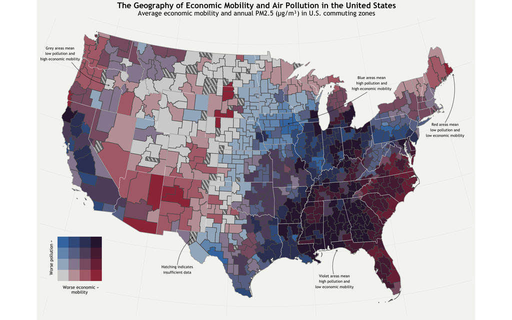

Figure 1: Economic Mobility and Air Pollution

This figure brings to attention the striking relationship between ambient air pollution levels and economic mobility. It also provides supporting evidence for air pollution playing a role in the perpetuation of low economic mobility. Additionally, it motivates a deeper examination of air pollution as a potentially causal mechanism for economic mobility. Finally, it exemplifies the usage of cutting-edge, satellite-based measures of air pollution for gaining a comprehensive understanding of the relationship between air pollution and social systems.

## Supplemental Material

Background materials on data and methods are available here.

## References

Borgschulte, Mark, David Molitor, and Eric Zou. 2022. *Air Pollution and the Labor Market: Evidence from Wildfire Smoke*. w29952. Cambridge, MA: National Bureau of Economic Research. doi: 10.3386/w29952.

Chetty, Raj, Nathaniel Hendren, Patrick Kline, and Emmanuel Saez. 2014. “Where Is the Land of Opportunity? The Geography of Intergenerational Mobility in the United States *.” *The Quarterly Journal of Economics* 129(4):1553–623. doi: 10.1093/qje/qju022.

Currie, Janet, and Reed Walker. 2011. “Traffic Congestion and Infant Health: Evidence from E-ZPass.” *American Economic Journal: Applied Economics* 3(1):65–90. doi: 10.1257/app.3.1.65.

Donkelaar, Aaron van, Melanie S. Hammer, Liam Bindle, Michael Brauer, Jeffery R. Brook, Michael J. Garay, N. Christina Hsu, Olga V. Kalashnikova, Ralph A. Kahn, Colin Lee, Robert C. Levy, Alexei Lyapustin, Andrew M. Sayer, and Randall V. Martin. 2021. “Monthly Global Estimates of Fine Particulate Matter and Their Uncertainty.” *Environmental Science & Technology* 55(22):15287–300. doi: 10.1021/acs.est.1c05309.

Wodtke, Geoffrey T., Kerry Ard, Clair Bullock, Kailey White, and Betsy Priem. 2022. “Concentrated Poverty, Ambient Air Pollution, and Child Cognitive Development.” *Science Advances* 8(48):eadd0285. doi: 10.1126/sciadv.add0285.